# Analytics Portfolio

## **Lifetime Value prediction using CRM data**

### **The pipeline included two steps:**

- **Segmentation of users according to their Length, Recency, Frequency, Monetary, Periodicity of transactions**  
  The original publication of this model can be found by entering [this link](https://www.emeraldinsight.com/doi/abs/10.1108/MIP-11-2016-0210).
- **Fitting a model that predicts future user engagement.**  
  Fitting a model per cluster was found to improve the balance between Sensitivity and Specificity, as well as capture the variable importance among users with similar transactional patterns. This framework was used as a prescriptive analysis to inform the strategic goals of a non-profit organisation.

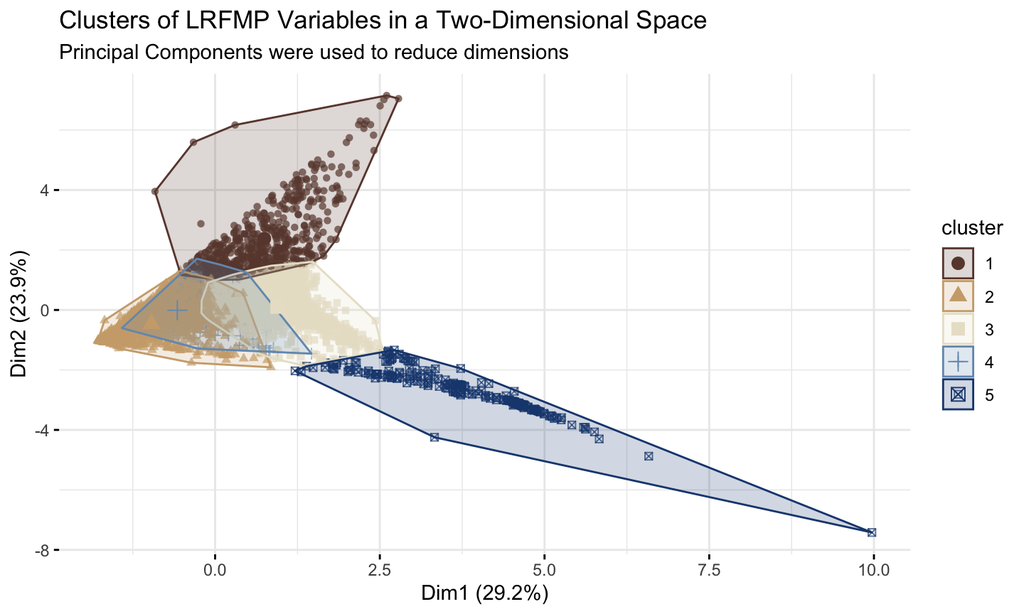

Five segments were identified, each with their own transactional patterns. A characterization was performed after further analysis of the clusters.

| Cluster | ROC AUC | Sensitivity | Specificity |
| --- | --- | --- | --- |
| 1 | 0.72 | 0.85 | 0.47 |
| 2 | 0.77 | 0 | 1 |
| 2 (SMOTE) | 0.79 | 0.42 | 0.91 |
| 3 | 0.81 | 0.47 | 0.89 |
| 4 | 0.78 | 0.57 | 0.8 |
| 5 | N/A | N/A | N/A |

A classification model was performed, gathering concepts from Churn Prediction and Lifetime Value models, adapting them to the problem to solve.

## **Cohort analysis**

Be able to directly see which behaviour drove to better or worse retention is key in building features that improve Lifetime Value.

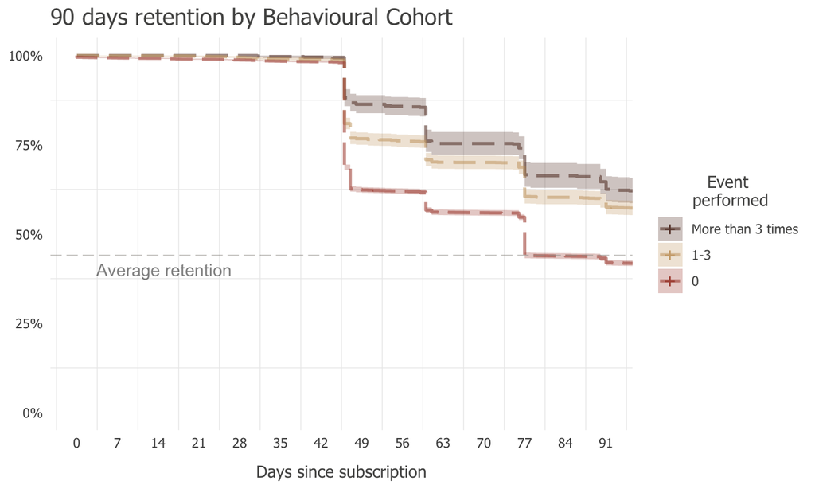

The usage of Survival Analysis to measure churn outperforms standard methods, as it can draw confidence intervals, adding rigour to the analysis.

## **Understand Machine Learning predictions**

By predicting a particular behaviour, such as churning or any other user interaction, the model will decode, from vast amounts of data, what drove users to perform that activity. However, Machine Learning models are black-boxes, so predicting is useless if there is no clear understanding of the model’s learnings.

Explainable Machine Learning techniques are used to make models become human readable. Performing this analysis can save hours of data exploration, as the model is able to get the patterns more efficiently.

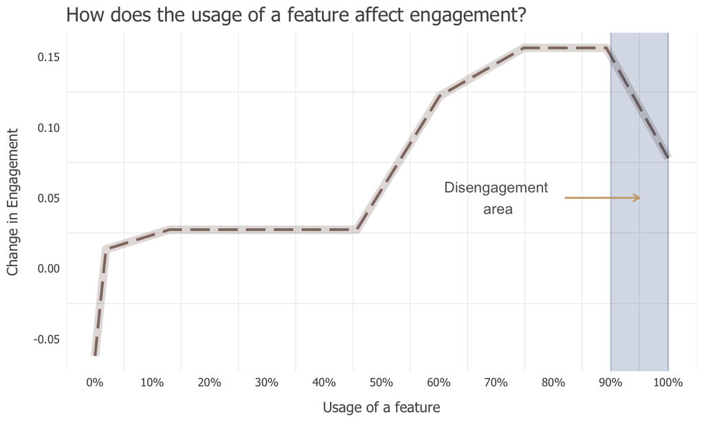

## **Interactive Web-Dashboards using reactive programming**

- **User behaviour tracker.**  
  User activity, critical events or activation points need monitoring. Being able to constantly see the changes in user behaviour and determine if goals are met can be game changer. To see an example access [this link](https://ftoresh.shinyapps.io/portfolio_dash/)
- **Rapid prototyping.**  
  Prototyping dashboards to get approval from stakeholders. Once approved, they can be replicated into a more complex information system.

## **Merge data from different sources to form a unique reality**

Click [here](https://www.youtube.com/watch?v=22a7iOIU6sw&feature=youtu.be) to see a real example of data gathered from two different sources, then joined to form a unique reality on a geospacial dashboard.

The code of this portfolio can be seen on my Github account following [this repository](https://github.com/ftoresh/Projects-Portfolio/blob/master/Behavioral%20analytics/Behavioral%20analytics%20portfolio.Rmd).